# Analysis of hunting effects on spatial structure of trees with different dispersers

Data preparation

Robert Bagchi

24 October, 2017

## 1. Preliminaries

### 1.1 Loading and installing libraries

If you need to install the `RSPPlme4` package, you can execute the following code. Note, you need the `devtools` package installed.

```r
##devtools::install_github('BagchiLab-Uconn/RSPPlme4')
```

We can then load all the necessary libraries.

```r
rm(list=ls())
# data organisation
library(abind)

library(reshape)
library(tidyr)
library(dplyr)
library(broom)

## spatial analysis
library(spatstat)
library(RSPPlme4)

## plotting
library(ggplot2)
library(cowplot)
library(grid)
library(gtable)
```

### 1.2 Define some useful functions for this analysis

- Function that standardises a vector (standardise)
- Function that takes the output from the model and puts it in a convenient format for plotting (klmerci2plot)
- Function that plots the BLUEs against distance (plot.klmerHyper)
- Function that plots the coefficient and confidence intervals from a bootstrap (plot.klmerci)
- Function to extract random effect BLUPs to allow plotting (extractModRanefs)
- Function to extract residuals and covariates for plotting (ExtractModResids)

```r
source("PeruConvenienceFunctions_klmer.R")
```

## 2. Read in and process data

### 2.1 Read in the data

```r
trees <- read.csv("../../data/mdd6plots_data_22jul2016.csv") ## tree locations
dispersal <-  read.csv("../../data/MDDspp_dispersal_syndromes_18jul2017.csv") ## dispersal data
sitedat <- read.csv("../../data/sitedata.csv") ## site information
```

```r
#Define maximum range over which to consider spatial patterns
rmax <- 15
## define dbh ranges of sizeclasses
dbhgroups <- data.frame(maxdbh = c(0.99, 1.99, 3.99, 9.99, 300),
                   labels = c("dbh_0", "dbh_1", "dbh_2", "dbh_4", "dbh_10"))

## size classes to include in analysis
sizeclasses <- c("dbh_0", "dbh_1", "dbh_2", "dbh_4", "dbh_10")[c(1:2, 5)]
minclass <- 1
```

### 2.2 Data organisation

#### 2.1.1 Organise the dispersal data

```r
# Put dispersal into 1/0 format by filling in the NAs with 0s
dispersal[, c('LV', 'SV', 'SB', 'Bat', 'TR', 'Wind', 'Expl', 'Unkwn', 'HSD')] <-
  apply(dispersal[, c('LV', 'SV', 'SB', 'Bat', 'TR', 'Wind', 'Expl', 'Unkwn', 'HSD')],
        2, function(x) ifelse(is.na(x), 0, x))
# combine wind and explosive dispersal into a single variable
dispersal$Abiotic <-  dispersal$Wind + dispersal$Expl
```

#### 2.2.2 Calculate hunting pressure

```r
sitedat$hunted <- relevel(sitedat$hunted, 'intact')
sitedat1 <- sitedat[!duplicated(sitedat$forest),]

sitedat1$huntpres <-
  with(sitedat1, (standardise(lg.primates) +
                   standardise(lg.birds) + standardise(md.primates)))*(-1)
sitedat$huntpres <- sitedat1$huntpres[match(sitedat$forest, sitedat1$forest)]

huntpresdat <- summarise(group_by(sitedat, forest),
          lg.primates=unique(lg.primates),
          md.primates=unique(md.primates),
          lg.birds=unique(lg.birds)) %>%
  mutate(huntpres = -1*(standardise(lg.primates) + standardise(md.primates) +
           standardise(lg.birds)))

sitedat$huntpres <- huntpresdat$huntpres[match(sitedat$forest, huntpresdat$forest)]
sitedat[order(sitedat$pname),] ## take a quick look
```

```
##        site forest pname hunted lg.primates lg.birds md.primates sm.primates
## 1        BM     BM    BM hunted         0.0      2.1         8.4        86.4
## 3  CashuTr3  Cashu   CC1 intact        37.5     29.2        50.7        74.2
## 2 CashuTr12  Cashu   CC2 intact        37.5     29.2        50.7        74.2
## 4        LA     LA    LA hunted         3.9     18.2        19.8        24.6
## 5        RA     RA    RA hunted         0.0      8.0         3.7        37.6
## 6       TRC    TRC   TRC intact        15.9     44.0        11.1         7.4
##   huntpres
## 1    2.352
## 3   -3.862
## 2   -3.862
## 4    0.543
## 5    2.251
## 6   -1.283
```

```r
quantile(sitedat$huntpres, c(0.25, 0.75))
```

```
##   25%   75%
## -3.22  1.82
```

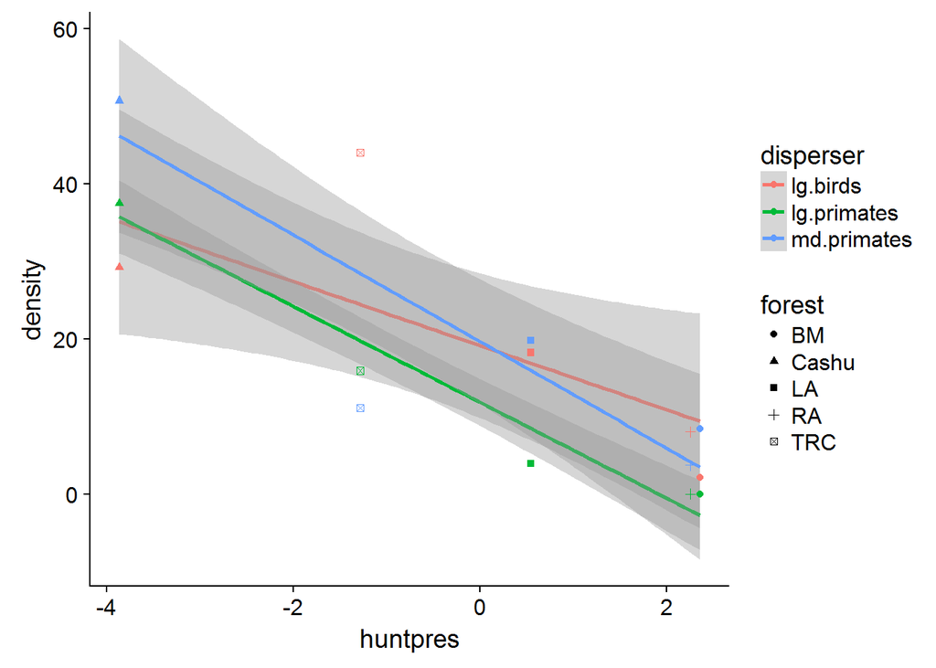

```r
gather(sitedat, disperser, density, lg.primates, md.primates, lg.birds) %>%
  ggplot(aes(x=huntpres, y= density, colour=disperser)) +
  geom_smooth(method='gam') + geom_point(aes(shape=forest))
```

#### 2.2.3 Organise spatial pattern data

Need to deal with colocated points and remove stems that are a. palms,  
b. unidentified (spcode = -999) c. have no dispersal data

```r
# First deal with duplicated points (same site, coordinates, code and Type) -
# sometimes these have different tags, but for our purposes, 2 points at the
# same location cause problems, so we add a little bit of noise to them
# (less than the resolution of the original data)
dups <- duplicated(trees[,c('Site', 'E', 'N', 'code', 'Type')])
sum(dups)## a total of 102 such points out of 67000, so not many
```

```
## [1] 102
```

```r
trees$E[dups]  <-  trees$E[dups] + runif(sum(dups), -0.1, 0.1)
trees$N[dups]  <-  trees$N[dups] + runif(sum(dups), -0.1, 0.1)

trees.old <- trees ## make a copy for comparison later on

## Remove palms
trees <-trees[-c(grep('Astrocaryum', trees$Spp),
                 grep('Attalea', trees$Spp),
                 grep('Iriartea', trees$Spp),
                 grep("Chamaedorea", trees$Spp)),] ## removing palms

nrow(trees.old) - nrow(trees) ## lose 3727 palms
```

```
## [1] 3727
```

```r
## remove unidentified stems
sum(trees$code==-999) ## removes 7154 unidentified stems
```

```
## [1] 7154
```

```r
trees <-  trees[trees$code != -999,]
nrow(trees) ## leaves us with 55870 stems
```

```
## [1] 55870
```

```r
## there are a few stems with missing dbh data - remove them too
trees <- trees[!is.na(trees$diam) | trees$Type == "S",]
```

We know split the data into cohorts based on size.

```r
trees$diam[trees$Type =="S"] <- 0.1 ## set sapling dbh to 0.1 (which isn't accurate,
#but works fine for our purposes - any value < 0.9 would work)

trees$Type <-  cut(trees$diam, breaks = c(0, dbhgroups$maxdbh),
                   labels = dbhgroups$labels, include.lowest=TRUE)

## remove adults with dbh < median dbh
## first calculate adult median dbh, but truncated so that the maximum is 30
truncmed <- function(x)
{
  out <- median(x)
  out <- ifelse(out > 15, 15, 10)
  return(out)
}


meddiam <- trees %>% filter(Type == dbhgroups$labels[length(dbhgroups$labels)]) %>%
  group_by(code) %>% summarize(med_dbh = truncmed(diam))

trees$adcutof <- meddiam$med_dbh[match(trees$code, meddiam$code)]

trees$dbhclass <- trees$Type
trees$Type[trees$Type == sizeclasses[length(sizeclasses)] &
             trees$diam < trees$adcutof] <- NA

abunddat <- trees %>%
  filter(Type %in% sizeclasses &
           !is.na(Type)) %>%
  group_by(code, Site, Type) %>%
  summarise(N = n_distinct(Tag))
abunddat <- droplevels(abunddat)

fulldat <- expand.grid(code = unique(abunddat$code),
                       Site = levels(abunddat$Site),
                       Type = levels(abunddat$Type))
abunddat <-  merge(abunddat, fulldat, by=c("code", "Site", "Type"),
                   all=TRUE) %>% replace_na(list(N=0))
abunddat <- merge(abunddat, sitedat[, c("site", "pname", "huntpres")],
                                    by.x="Site", by.y="site", all=TRUE)
abunddat <- merge(abunddat, dispersal[, 1:11])

trees <- subset(trees, Type %in% sizeclasses)


## Now get the abundance of each species x type x site combination
## and merge it into the dataset
abund <- aggregate(Tag ~ Spp + code + Type + Site, data=trees, length)
names(abund)[5] <- 'abund'

abund <- spread(abund, Type, abund, fill=0)
names(abund)[grep("dbh", names(abund))] <-
  paste('N', names(abund)[grep("dbh", names(abund))], sep='.')

abund$hasdisp <- abund$code %in% dispersal$code
## now working out if there is enough replication at each
## species and site combination for

## must have at least 1 pair of smallest size class, plus at least 1 pair
## in either of the two larger recruit groups
abund$Quni <-  abund[,paste("N", sizeclasses[1], sep=".")] > 1 &
  apply(as.matrix(abund[, paste("N", sizeclasses[2:(length(sizeclasses)-1)], sep='.')]),
        1, function(x) sum(x>1)>=minclass) &
    abund[, "hasdisp"]

abund$Qbi <-  abund$Quni &
  (abund[ , paste("N", sizeclasses[length(sizeclasses)], sep='.')] > 1)


## Some preliminary numbers of how many stems and species qualify
sum(abund$Quni); sum(abund$Qbi) ##
```

```
## [1] 533
```

```
## [1] 378
```

```r
apply(abund[abund$Quni, paste0("N.", sizeclasses)], 2, sum)
```

```
##  N.dbh_0  N.dbh_1 N.dbh_10
##     9400    10045     6520
```

```r
apply(abund[abund$Qbi, paste0("N.", sizeclasses)], 2, sum)
```

```
##  N.dbh_0  N.dbh_1 N.dbh_10
##     7471     7850     6462
```

```r
trees <- merge(trees, abund, by=c('Spp', 'code', 'Site'), all =T)
trees$Spp <- droplevels(trees$Spp)
nlevels(trees$Spp)
```

```
## [1] 703
```

```r
library(glmmTMB)
abunddat <- subset(abunddat, !(Unkwn > 0 | Wind > 0 | Expl > 1))

mod1 <- glmmTMB(N~Type*huntpres*HSD + (1|Site/code),
              data=abunddat, family=nbinom2)
summary(mod1)
```

```
##  Family: nbinom2  ( log )
## Formula:          N ~ Type * huntpres * HSD + (1 | Site/code)
## Data: abunddat
##
##      AIC      BIC   logLik deviance df.resid
##    18958    19054    -9464    18928     4557
##
## Random effects:
##
## Conditional model:
##  Groups    Name        Variance Std.Dev.
##  code:Site (Intercept) 5.2267   2.286
##  Site      (Intercept) 0.0213   0.146
## Number of obs: 4572, groups:  code:Site, 1524; Site, 6
##
## Overdispersion parameter for nbinom2 family (): 1.31
##
## Conditional model:
##                         Estimate Std. Error z value Pr(>|z|)
## (Intercept)              -0.1275     0.1337   -0.95   0.3404
## Typedbh_1                 0.1024     0.0764    1.34   0.1799
## Typedbh_10               -0.2034     0.0835   -2.44   0.0148 *
## huntpres                 -0.1414     0.0480   -2.94   0.0032 **
## HSD                      -0.2105     0.1865   -1.13   0.2591
## Typedbh_1:huntpres        0.0452     0.0276    1.64   0.1012
## Typedbh_10:huntpres       0.0484     0.0301    1.61   0.1077
## Typedbh_1:HSD            -0.0902     0.1260   -0.72   0.4740
## Typedbh_10:HSD            0.5644     0.1338    4.22  2.5e-05 ***
## huntpres:HSD              0.0625     0.0684    0.91   0.3611
## Typedbh_1:huntpres:HSD    0.0294     0.0455    0.65   0.5182
## Typedbh_10:huntpres:HSD  -0.0214     0.0481   -0.44   0.6572
## ---
## Signif. codes:  0 '***' 0.001 '**' 0.01 '*' 0.05 '.' 0.1 ' ' 1
```

```r
mod2 <- glmmTMB(N~(Type + huntpres + HSD)^2 + (1|Site/code),
              data=abunddat, family=nbinom2)
summary(mod2)
```

```
##  Family: nbinom2  ( log )
## Formula:          N ~ (Type + huntpres + HSD)^2 + (1 | Site/code)
## Data: abunddat
##
##      AIC      BIC   logLik deviance df.resid
##    18955    19038    -9464    18929     4559
##
## Random effects:
##
## Conditional model:
##  Groups    Name        Variance Std.Dev.
##  code:Site (Intercept) 5.2273   2.286
##  Site      (Intercept) 0.0213   0.146
## Number of obs: 4572, groups:  code:Site, 1524; Site, 6
##
## Overdispersion parameter for nbinom2 family (): 1.31
##
## Conditional model:
##                     Estimate Std. Error z value Pr(>|z|)
## (Intercept)          -0.1290     0.1333   -0.97   0.3330
## Typedbh_1             0.1144     0.0741    1.54   0.1226
## Typedbh_10           -0.2117     0.0811   -2.61   0.0090 **
## huntpres             -0.1425     0.0465   -3.06   0.0022 **
## HSD                  -0.2075     0.1850   -1.12   0.2621
## Typedbh_1:huntpres    0.0586     0.0182    3.22   0.0013 **
## Typedbh_10:huntpres   0.0375     0.0192    1.96   0.0504 .
## Typedbh_1:HSD        -0.1145     0.1199   -0.96   0.3392
## Typedbh_10:HSD        0.5806     0.1277    4.55  5.4e-06 ***
## huntpres:HSD          0.0649     0.0632    1.03   0.3044
## ---
## Signif. codes:  0 '***' 0.001 '**' 0.01 '*' 0.05 '.' 0.1 ' ' 1
```

```r
mod2.1 <-  update(mod2, ~.-Type:huntpres)
mod2.2 <-  update(mod2, ~.-Type:HSD)
mod2.3 <-  update(mod2, ~.-HSD:huntpres)

anova(mod1, mod2) ## 3 way ns - no evidence that hunting reduces LV dispersed species
```

```
## Data: abunddat
## Models:
## mod2: N ~ (Type + huntpres + HSD)^2 + (1 | Site/code), zi=~0, disp=~1
## mod1: N ~ Type * huntpres * HSD + (1 | Site/code), zi=~0, disp=~1
##      Df   AIC   BIC logLik deviance Chisq Chi Df Pr(>Chisq)
## mod2 13 18955 19038  -9464    18929
## mod1 15 18957 19054  -9464    18927  1.11      2       0.58
```

```r
                  ## more
anova(mod2, mod2.1) ## juveniles significantly more abundant in hunted forests
```

```
## Data: abunddat
## Models:
## mod2.1: N ~ Type + huntpres + HSD + (1 | Site/code) + Type:HSD + huntpres:HSD, zi=~0, disp=~1
## mod2: N ~ (Type + huntpres + HSD)^2 + (1 | Site/code), zi=~0, disp=~1
##        Df   AIC   BIC logLik deviance Chisq Chi Df Pr(>Chisq)
## mod2.1 11 18961 19032  -9470    18939
## mod2   13 18955 19038  -9464    18929  10.6      2     0.0049 **
## ---
## Signif. codes:  0 '***' 0.001 '**' 0.01 '*' 0.05 '.' 0.1 ' ' 1
```

```r
anova(mod2, mod2.2) ## LV dispersed adults significantly more abundant OVERALL!
```

```
## Data: abunddat
## Models:
## mod2.2: N ~ Type + huntpres + HSD + (1 | Site/code) + Type:huntpres + , zi=~0, disp=~1
## mod2.2:     huntpres:HSD, zi=~0, disp=~1
## mod2: N ~ (Type + huntpres + HSD)^2 + (1 | Site/code), zi=~0, disp=~1
##        Df   AIC   BIC logLik deviance Chisq Chi Df Pr(>Chisq)
## mod2.2 11 18983 19054  -9481    18961
## mod2   13 18955 19038  -9464    18929  32.7      2    8.1e-08 ***
## ---
## Signif. codes:  0 '***' 0.001 '**' 0.01 '*' 0.05 '.' 0.1 ' ' 1
```

```r
                    ## Not evidence that hunting affects LV dispersed species more.
anova(mod2, mod2.3) ## No interaction between hunting and reliance on hunted dispersers
```

```
## Data: abunddat
## Models:
## mod2.3: N ~ Type + huntpres + HSD + (1 | Site/code) + Type:huntpres + , zi=~0, disp=~1
## mod2.3:     Type:HSD, zi=~0, disp=~1
## mod2: N ~ (Type + huntpres + HSD)^2 + (1 | Site/code), zi=~0, disp=~1
##        Df   AIC   BIC logLik deviance Chisq Chi Df Pr(>Chisq)
## mod2.3 12 18954 19031  -9465    18930
## mod2   13 18955 19038  -9464    18929  1.05      1        0.3
```

```r
library(vegan)
```

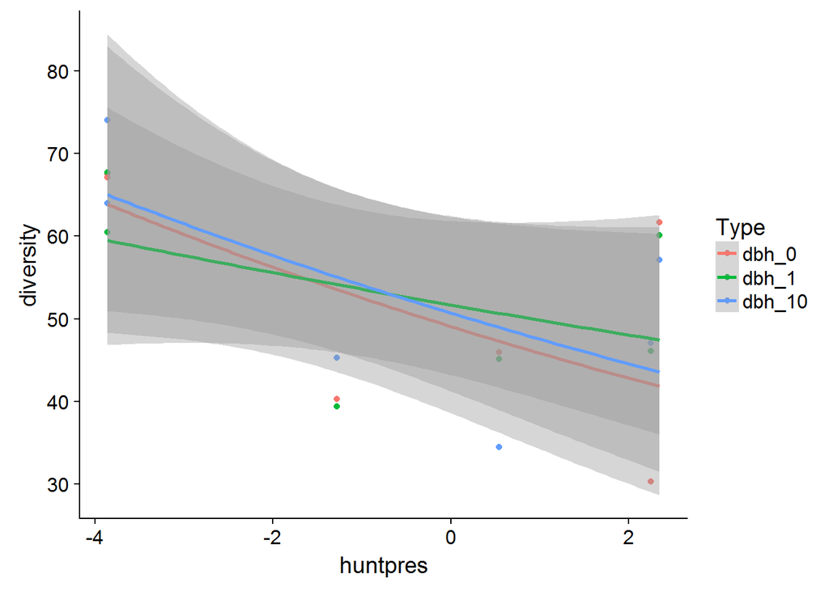

```r
spdiv <- abunddat %>% group_by(Type, Site) %>%
  summarise(diversity = exp(diversity(N)))

spdiv <- merge(spdiv, sitedat[, c("site","huntpres")],
               by.x="Site", by.y="site")
ggplot(spdiv, aes(x=huntpres, y=diversity, colour=Type)) +
  geom_point() + geom_smooth(method="glm",
                             method.args=list(family=gaussian(link="log")))
```

```r
mod.div <- glm(diversity~huntpres*Type, family=gaussian(link="log"), data=spdiv)
summary(mod.div)
```

```
##
## Call:
## glm(formula = diversity ~ huntpres * Type, family = gaussian(link = "log"),
##     data = spdiv)
##
## Deviance Residuals:
##     Min       1Q   Median       3Q      Max
## -14.763   -8.739   -0.008    7.110   19.824
##
## Coefficients:
##                     Estimate Std. Error t value Pr(>|t|)
## (Intercept)          3.89370    0.11083   35.13  1.8e-13 ***
## huntpres            -0.06805    0.03762   -1.81    0.096 .
## Typedbh_1            0.05165    0.15076    0.34    0.738
## Typedbh_10           0.03252    0.15397    0.21    0.836
## huntpres:Typedbh_1   0.03166    0.05232    0.61    0.556
## huntpres:Typedbh_10  0.00373    0.05240    0.07    0.944
## ---
## Signif. codes:  0 '***' 0.001 '**' 0.01 '*' 0.05 '.' 0.1 ' ' 1
##
## (Dispersion parameter for gaussian family taken to be 150)
##
##     Null deviance: 2848.2  on 17  degrees of freedom
## Residual deviance: 1798.0  on 12  degrees of freedom
## AIC: 148
##
## Number of Fisher Scoring iterations: 6
```

```r
anova(mod.div, test="F")
```

```
## Analysis of Deviance Table
##
## Model: gaussian, link: log
##
## Response: diversity
##
## Terms added sequentially (first to last)
##
##
##               Df Deviance Resid. Df Resid. Dev    F Pr(>F)
## NULL                             17       2848
## huntpres       1      983        16       1866 6.56  0.025 *
## Type           2        7        14       1859 0.02  0.978
## huntpres:Type  2       61        12       1798 0.20  0.819
## ---
## Signif. codes:  0 '***' 0.001 '**' 0.01 '*' 0.05 '.' 0.1 ' ' 1
```

This analysis suggests that hunting doesn’t disproportinately affect tree species dispersed by hunted vertebrates. There is some evidence that high HSD species have lower sapling:adult ratios (fewer saplings per adult), but that is true across the board. There is also evidence that all zoochorous species have lower sapling:adult ratios as defaunation increases. However, it seems unlikely that small bird dispersed species would be affected too. Perhaps there is another mechanism here. There is no effect of hunting on changes in diversity through cohorts - the trend with the main effect of huntpres is an artefact of spatial variation in diversity.

### 2.3 Calculate the K functions

Define the plot boundaries

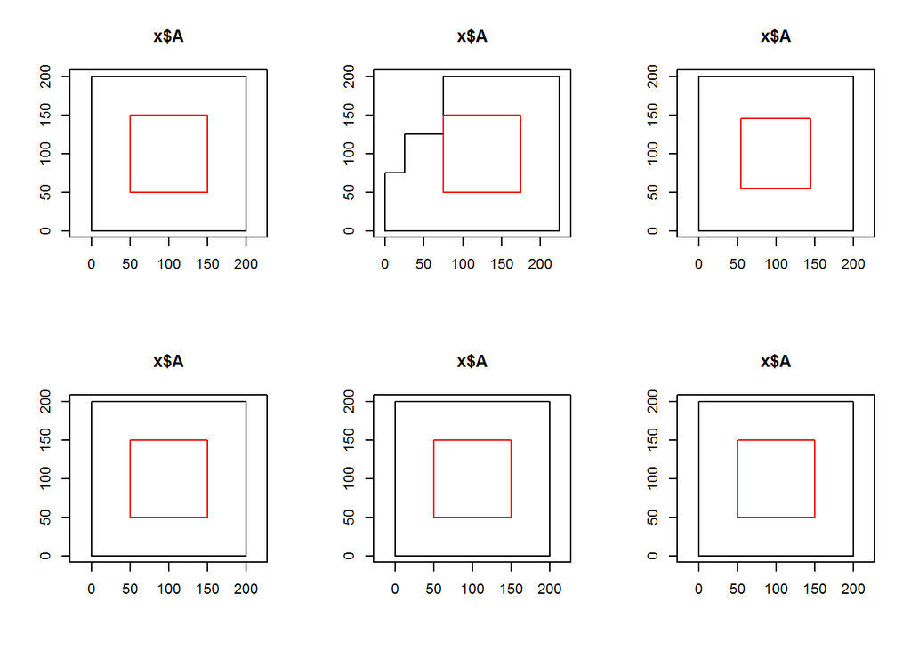

```
## $BM
## window: rectangle = [50, 150] x [50, 150] units
##
## $CashuTr12
## window: rectangle = [75, 175] x [50, 150] units
##
## $CashuTr3
## window: rectangle = [55, 145] x [55, 145] units
##
## $LA
## window: rectangle = [50, 150] x [50, 150] units
##
## $RA
## window: rectangle = [50, 150] x [50, 150] units
##
## $TRC
## window: rectangle = [50, 150] x [50, 150] units
```

```r
## defining the window at CC12 which is not quite rectangular
cc12  <- owin(poly=list(x=c(225, 75, 75, 24.9, 25, 0, 0, 225),
                        y= c(200, 200, 125, 125, 75, 75, 0, 0)))

## defining a list of windows for each site
## Each comprises of a window for each size class.
winlist <- list(BM=list(A=owin(c(0, 200), c(0, 200)),
                        R=owin(c(50, 150), c(50, 150))),
                CashuTr12=list(A=cc12,
                               R=owin(c(75, 175), c(50, 150))),
                CashuTr3=list(A=owin(c(0, 200), c(0, 200)),
                              R=owin(c(55, 145), c(55, 145))),
                LA=list(A=owin(c(0, 200), c(0, 200)),
                        R=owin(c(50, 150), c(50, 150))),
                RA=list(A=owin(c(0, 200), c(0, 200)),
                        R=owin(c(50, 150), c(50, 150))),
                TRC=list(A=owin(c(0, 200), c(0, 200)),
                         R=owin(c(50, 150), c(50, 150))))

par(mfrow=c(2,3))
lapply(winlist, function(x) { plot(x$A, axes=T, asp=1)
  plot(x$R, add=T, border=2)}) ## looks ok
```

Split the data by site and pull out species lists

```r
trees <- split(trees, f=trees$Site)
## Pull out some summary stats
sapply(trees, nrow)
```

```
##        BM CashuTr12  CashuTr3        LA        RA       TRC
##      5175      6203      7144      7302      7966      6166
```

```r
sapply(trees, function(x) length(unique(x$Spp)))
```

```
##        BM CashuTr12  CashuTr3        LA        RA       TRC
##       315       311       442       268       250       231
```

```r
## make a species list for each plot (based on the species that have sufficient
## stems in each size class
## Univariate analysis
splists.uni <- lapply(trees, function(dat) unique(dat$code[dat$Quni]))

## bivariate analysis
splists.bi <- lapply(trees, function(dat) unique(dat$code[dat$Qbi]))
```

```r
ppp.sps.uni <- mapply(function(spid, treedat, win)
{
  ppp.sp <- lapply(as.list(spid), function(id, treedat, win)
  {

    treedat <- droplevels(treedat[treedat$Type !="dbh.10",])
    win <- win[['R']]
    condat <- treedat[treedat$code==id,] ## subset data from species
    ppp.con <- lapply(split(condat, f=condat$Type), function(Tx, Wx)
    { ## turn into ppp object
      pppx <- ppp(x=Tx$E, y=Tx$N, window=Wx)
      return(pppx)
    },  Wx=win)

    ## note that species are split by size-class (Type) when input to the function
    ## now heterospecifics
    hetdat <- treedat[treedat$code!=id,] ## subset out all heterspecifics
    ## Note that this will include species
    ## not included in elsewhere in the analysis

    ppp.het <- lapply(split(hetdat, f=hetdat$Type), function(Tx, Wx)
    {
      Tx <- Tx[!duplicated(Tx[,c('E', 'N')]),] ## remove colocated stems
      pppx <- ppp(x=Tx$E, y=Tx$N, window=Wx)

      return(pppx)
    }, Wx=win)
    summary(hetdat[hetdat$Type == "dbh.7",])
    names(ppp.het) <- paste(names(ppp.het), 'h', sep='') ## add 'h' suffix to het names
    ppp.sp <- c(ppp.con, ppp.het) ## combine cons and hets
    return(ppp.sp)
  }, treedat=treedat, win=win)

  names(ppp.sp) <- spid
  return(ppp.sp)
}, spid=splists.uni, treedat=trees, win=winlist, SIMPLIFY=FALSE)


winlist2 <- lapply(winlist, function(win){

  sitewin <- sapply(sizeclasses, function(x) win$R, simplify=FALSE)
  sitewin[[length(sitewin)]] <- win$A
  return(sitewin)
})

## Now for the bivariate case.
ppp.sps.bi <- mapply(function(spid, treedat, win)
{
  ppp.sp <- lapply(as.list(spid), function(id, treedat, win)
  {

    condat <- treedat[treedat$code==id,] ## subset data from species
    ppp.con <- mapply(function(Tx, Wx)
    { ## turn into ppp object
      pppx <- ppp(x=Tx$E, y=Tx$N, window=Wx)
      return(pppx)
    }, Tx=split(condat, f=condat$Type), Wx=win, SIMPLIFY=FALSE)

    ## note that species are split by size-class (Type) when input to the function
    ## now heterospecifics

    hetdat <- treedat[treedat$code!=id,] ## subset out all heterspecifics
    ## Note that this will include species
    ## not included in elsewhere in the analysis
    ppp.het <- mapply(function(Tx, Wx)
    {
      Tx <- Tx[!duplicated(Tx[,c('E', 'N')]),] ## remove colocated stems
      pppx <- ppp(x=Tx$E, y=Tx$N, window=Wx)

      return(pppx)
    }, Tx=split(hetdat, f=hetdat$Type), Wx=win, SIMPLIFY=FALSE)

    names(ppp.het) <- paste(names(ppp.het), 'h', sep='') ## add 'h' suffix to het names
    ppp.sp <- c(ppp.con, ppp.het) ## combine cons and hets
    return(ppp.sp)},
  treedat=treedat, win=win)
  names(ppp.sp) <- spid
  return(ppp.sp)
}, spid=splists.bi, treedat=trees, win=winlist2, SIMPLIFY=FALSE)

## Remove species with adults only on the edge of the plot
## not very common, but causes problems when it does
ppp.sps.bi <-
  mapply(function(site.dat, site.win)
  {
    site.dat[sapply(site.dat, function(sp.dat, site.win)
    {
      npoints(sp.dat[[sizeclasses[length(sizeclasses)]]][dilation(site.win$R, rmax)])
    }, site.win=site.win) > 0]
  }, site.dat = ppp.sps.bi, site.win=winlist, SIMPLIFY=FALSE)
```

## 3. K function calculations

We can now calculate the K functions for both the univariate and bivariate analyses.

### 3.1 Univariate K functions

The code below constructs a hyperframe (see the spatstat package) which includes the covariates, point patterns and K functions in a single object.

```r
hyperdat.uni  <- mapply(function(dat,sitenms, sc)
{
  sc <- sc[-length(sc)]
  hyper <- hyperframe(
    site=sitenms,
    sp.id = rep(names(dat), length(sc)), ## 1 each for each sizeclass
    stage = factor(rep(sc, each=length(dat))),
    pppx=do.call('c', lapply(sc, function(dbh)
    {
      lapply(dat, function(x) x[[dbh]])
    })),
    pppy=do.call('c', lapply(sc, function(dbh)
    {
      dbh <- paste0(as.character(dbh), 'h')
      lapply(dat, function(x) x[[dbh]])
    })))

  ## Add site data
  hyper <- cbind.hyperframe(hyper,
                            sitedat[match(hyper$site, sitedat$site),
                                    c('forest', 'pname', 'hunted',
                                      'lg.primates', 'lg.birds', 'huntpres')])

  hyper$N1 <- sapply(hyper$pppx, npoints) # no. conspecifics
  hyper$N2 <- sapply(hyper$pppy, npoints) # no. heterospecifics

  # Add dispersal data
  hyper <- cbind.hyperframe(hyper,
                            dispersal[match(hyper$sp.id, dispersal$code),
                                      c('Spp', 'LV', 'SV', 'SB', 'Bat',
                                        'TR', 'Wind', 'Expl',
                                        'Unkwn', 'Abiotic', 'HSD')])
  hyper <- subset(hyper, N1 > 1)

  ## Concpecific K function
  Kcon <- with(hyper, Kest(pppx, r=0:rmax, correction="border",
                           ratio=TRUE))
  ## Heterospecific K function
  ppp.s <- with(hyper, superimpose(i=pppx, j=pppy, W=pppy$window))
  Khet <- lapply(ppp.s, function(ppp.s)
    Kmulti(ppp.s, I=marks(ppp.s)=='i', J= marks(ppp.s)=='j',
           r=0:rmax, correction="border", ratio=TRUE))

  ## Correct conspecific K function for inhomogeneities in
  ## overall tree density by subtracting Khet from Kcon
  hyper$K <-  mapply(function(conK, hetK){
    K <- conK
    K$border <- conK$border - hetK$border
    K$theo <- conK$theo - hetK$theo
    return(K)}, conK=Kcon, hetK=Khet, SIMPLIFY=FALSE)

  hyper$wts <-  lapply(hyper$pppx, function(pppx)
    kfuncWeightsCalc(pppx=pppx, r=0:rmax,
                       correction='border', type='sqrtnxny_A'))

  return(hyper)
}, dat = ppp.sps.uni, sitenms=as.list(names(ppp.sps.uni)),
MoreArgs=list(sc=sizeclasses), SIMPLIFY=FALSE)
```

We now do a final cut of species x site combinations with insufficient data. Even if there are enough points, too many individuals may be on the border and so are removed when border corrections are applied. We need at least one individual within the inner (minus-sampled) region. The easiest way to do this is to find `NAs` in the K functions and remove them

```r
## We need to remove data from sizeclasses without enough data
## Find list of species with NAs in K functions
keeplist <- lapply(hyperdat.uni, function(d)
  sapply(d$K, function(dk) !any(is.na(dk$border))))
## Remove those site x species x size class combinations,
## then remove sites x species that no longer satisfy the requirements for analysis
hyperdat.uni.sel <- mapply(function(dat, spkp){
  dat <- dat[spkp,]

  itab <- table(dat$sp.id, dat$stage)
  rmlist <- (which(itab[,1]==0)) ## identify species that don't have saplings
  ## identify speices that don't have at least minclass additonal non-zero size classes
  rmlist <- c(rmlist,
              which(apply(as.matrix(itab[,sizeclasses[-c(1, length(sizeclasses))]]),
                    1, function(x) sum(x) < minclass)))
  dat <- dat[!(dat$sp.id %in% names(rmlist)),]
  return(dat)
}, dat=hyperdat.uni, spkp=keeplist, SIMPLIFY=FALSE)


## gives us the number of speciesxsite combinations and for each site.
sum(sapply(hyperdat.uni.sel, function(x) length(unique(x$Spp))))
```

```
## [1] 455
```

```r
sapply(hyperdat.uni.sel, function(x) length(unique(x$Spp)))
```

```
##        BM CashuTr12  CashuTr3        LA        RA       TRC
##        70        88        89        72        75        61
```

```r
## make one hyperframe with all the data
hyperdat.uni.sel <- do.call('rbind', hyperdat.uni.sel)
## We can now remove unused levels
hyperdat.uni.sel$sp.id <- droplevels(hyperdat.uni.sel$sp.id)
hyperdat.uni.sel$Spp <- droplevels(hyperdat.uni.sel$Spp)
```

### 3.2 Bivariate K-functions

The bivariate calculations are similar to the univariate ones, except we are now interested in adult neighbours.

```r
hyperdat.bi  <- mapply(function(dat, sitenms, sc)
{
  sa <- sc[length(sc)]
  sc <- sc[-length(sc)]
  hyper <- hyperframe(
    site=sitenms,
    sp.id = rep(names(dat), length(sc)), ## 1 each for each sizeclass
    stage = factor(rep(sc, each=length(dat))),
    pppx=do.call('c', lapply(sc, function(dbh)
    {
      lapply(dat, function(x) x[[dbh]])
    })),
    pppy = rep(lapply(dat, function(x) x[[sa]]), length(sc)),
    ppphet = rep(lapply(dat, function(x) x[[paste0(sa, "h")]]), length(sc))
  )


  hyper <- cbind.hyperframe(hyper,
                            sitedat[match(hyper$site, sitedat$site),
                                    c('forest', 'pname', 'hunted',
                                      'lg.primates', 'lg.birds', 'huntpres')])

  hyper$N1 <- sapply(hyper$pppx, npoints)
  hyper$N2 <- sapply(hyper$pppy, npoints)

  hyper <- subset(hyper, N1 > 1)

  hyper <- cbind.hyperframe(hyper,
                            dispersal[match(hyper$sp.id, dispersal$code),
                                      c('Spp', 'LV', 'SV', 'SB', 'Bat', 'TR',
                                        'Wind', 'Expl',
                                        'Unkwn', 'Abiotic','HSD')])


  ppp.s <- with(hyper, superimpose(i=pppx, j=pppy, W=pppy$window))

  Kcon <- lapply(ppp.s, function(x)
    Kmulti(x, I=x$marks =='i', J=x$marks=='j',
           r=0:rmax, corr='border', ratio=TRUE))

  ppp.het <- with(hyper, superimpose(i=pppx, j=ppphet, W=ppphet$window))
  Khet <- lapply(ppp.het, function(x)
    Kmulti(x, I=x$marks =='i', J=x$marks=='j',
           r=0:rmax, corr='border', ratio=TRUE))
  hyper$K <- mapply(function(conK, hetK){
    K <- conK
    K$border <- conK$border - hetK$border
    K$theo <- conK$theo - hetK$theo
    return(K)}, conK=Kcon, hetK=Khet, SIMPLIFY=FALSE)

  hyper$wts <-  mapply(function(pppx, pppy)
    kfuncWeightsCalc(pppx=pppx, pppy=pppy, r=0:rmax,
                       correction='border', type='sqrtnxny_A'),
    pppx=hyper$pppx, pppy=hyper$pppy, SIMPLIFY=FALSE)

  return(hyper)
}, dat=ppp.sps.bi, sitenms=as.list(names(ppp.sps.bi)),
MoreArgs=list(sc=sizeclasses), SIMPLIFY=FALSE)
```

Because we are using plus-sampling rather than minus-sampling for the bivariate analysis, we don’t need to do a final cut of speices as we did in the univariate case.

Later analysis reveals that some species/site combinations are major outliers in the bivariate analysis. We could remove them in individual analyses, but that starts to get messy and could lead to errors. To deal with this problem once and for all, we remove them here

```r
## gives us the number of speciesxsite combinations and for each site.
sum(sapply(hyperdat.bi, function(x) length(unique(x$Spp))))
```

```
## [1] 296
```

```r
sapply(hyperdat.bi, function(x) length(unique(x$Spp)))
```

```
##        BM CashuTr12  CashuTr3        LA        RA       TRC
##        41        62        55        42        49        47
```

```r
hyperdat.bi <- do.call('rbind', hyperdat.bi)
summary(hyperdat.bi)
```

```
## hyperframe with 592 rows and 27 columns
##         site         sp.id       stage     pppx  pppy  ppphet   forest
##     (factor)      (factor)     (factor)    (ppp) (ppp)  (ppp) (factor)
##  BM       : 82   169    : 12   dbh_0:296                      BM   : 82
##  CashuTr12:124   306    : 12   dbh_1:296                      Cashu:234
##  CashuTr3 :110   597    : 12                                  LA   : 84
##  LA       : 84   611    : 12                                  RA   : 98
##  RA       : 98   628    : 12                                  TRC  : 94
##  TRC      : 94   664    : 12
##                  (Other):520
##  pname        hunted     lg.primates      lg.birds       huntpres
##  (factor)   (factor)       (numeric)     (numeric)      (numeric)
##  BM : 82   intact:328   Min.   : 0.0   Min.   : 2.1   Min.   :-3.86
##  CC1:110   hunted:264   1st Qu.: 0.0   1st Qu.: 8.0   1st Qu.:-3.86
##  CC2:124                Median :15.9   Median :29.2   Median :-1.28
##  LA : 84                Mean   :17.9   Mean   :22.7   Mean   :-0.96
##  RA : 98                3rd Qu.:37.5   3rd Qu.:29.2   3rd Qu.: 2.25
##  TRC: 94                Max.   :37.5   Max.   :44.0   Max.   : 2.35
##
##        N1            N2                        Spp            LV
##  (integer)     (integer)                  (factor)      (numeric)
##  Min.   :  2   Min.   : 1.0   Celtis schippii    : 12   Min.   :0.000
##  1st Qu.:  5   1st Qu.: 1.0   Guarea macrophylla : 12   1st Qu.:0.000
##  Median : 11   Median : 3.0   Pseudolmedia laevis: 12   Median :0.600
##  Mean   : 23   Mean   : 5.7   Quararibea wittii  : 12   Mean   :0.495
##  3rd Qu.: 24   3rd Qu.: 6.0   Ruizodendron ovale : 12   3rd Qu.:0.800
##  Max.   :463   Max.   :80.0   Sorocea pileata    : 12   Max.   :1.000
##                               (Other)            :520
##        SV              SB             Bat              TR            Wind
##  (numeric)       (numeric)       (numeric)       (numeric)      (numeric)
##  Min.   :0.000   Min.   :0.000   Min.   :0.000   Min.   :0.00   Min.   :0.00
##  1st Qu.:0.000   1st Qu.:0.000   1st Qu.:0.000   1st Qu.:0.00   1st Qu.:0.00
##  Median :0.000   Median :0.000   Median :0.000   Median :0.00   Median :0.00
##  Mean   :0.132   Mean   :0.189   Mean   :0.097   Mean   :0.03   Mean   :0.03
##  3rd Qu.:0.200   3rd Qu.:0.200   3rd Qu.:0.000   3rd Qu.:0.00   3rd Qu.:0.00
##  Max.   :1.000   Max.   :1.000   Max.   :1.000   Max.   :1.00   Max.   :1.00
##
##       Expl           Unkwn          Abiotic           HSD        K
##  (numeric)       (numeric)        (numeric)      (numeric)       (rat)
##  Min.   :0.000   Min.   :0.000   Min.   :0.000   Min.   :0.000
##  1st Qu.:0.000   1st Qu.:0.000   1st Qu.:0.000   1st Qu.:0.000
##  Median :0.000   Median :0.000   Median :0.000   Median :0.600
##  Mean   :0.014   Mean   :0.014   Mean   :0.044   Mean   :0.495
##  3rd Qu.:0.000   3rd Qu.:0.000   3rd Qu.:0.000   3rd Qu.:0.800
##  Max.   :1.000   Max.   :1.000   Max.   :1.000   Max.   :1.000
##
##  wts
##  (numeric)
##
##
##
##
##
##
##
```

```r
## Removing those species now
hyperdat.bi.sel <- subset(hyperdat.bi, !((sp.id == 187 & pname=='CC2')))
#                                            (sp.id==314 & pname=='CC2') |
#                                            (sp.id==38 & pname=='LA') |
#                                            (sp.id==144 & pname=='LA') |
#                                            (sp.id==226 & pname=="CC2") |
#                                            sp.id == 712 & pname=="TRC")
# )
## We can now remove unused levels
hyperdat.bi.sel$sp.id <- droplevels(hyperdat.bi.sel$sp.id)
hyperdat.bi.sel$Spp <- droplevels(hyperdat.bi.sel$Spp)
nlevels(hyperdat.bi.sel$Spp)
```

```
## [1] 147
```

```r
aggregate(sp.id ~ site, hyperdat.bi.sel, function(x) length(unique(x)))
```

```
##        site sp.id
## 1        BM    41
## 2 CashuTr12    62
## 3  CashuTr3    55
## 4        LA    42
## 5        RA    49
## 6       TRC    47
```

## 4. Finalise datasets

At this point it is useful to save the objects we have created and are required for analysis so we don’t always have to repeat processing and to minimise processing on the cluster. We save our results as a data object.

```r
nsclass <- length(sizeclasses)-1
save('dispersal', "sitedat", 'hyperdat.uni.sel', 'hyperdat.bi.sel',
     'ppp.sps.uni', "ppp.sps.bi", 'trees', 'winlist', 'rmax', 'minclass', 'sizeclasses',
      file=paste0("../data/data4peruanalysis_v8.3_", nsclass, "class.RData"))
```